# Social Media Censorship and Political Action in Democracies

Author

Affiliation

Norah Rami

University of Pennsylvania

Published

May 11, 2025

## Introduction

Social media is a political battle between activists wishing to speak out against repression and governments wishing to control dissent. Canadian political scientist, Ronald Deibert defines this tension as the era of “contested access” (Ronald Deibert et al. 2012). Social media has the potential to increase information access and encourage collective organizing. Even in the face of government crackdowns in Saudi Arabia, activists took to Twitter to criticize the ruling family and call for regime change [Pan and Siegel (2020). Most scholars credit the internet, with a particular emphasis on Facebook, as catalyzing the Arab Spring uprising (Ruijgrok 2017). Significant literature has identified social media’s ability to create a network of diverse people with similar grievances and enable them to recruit, organize, and coordinate action (Meserve and Pemstein 2020). Social media allows networked movement to reach and persuade peripheral individuals to join and act.

Facebook CEO, Mark Zuckerberg’s grand claimed that, “Social media will, left to its own devices, bring about a new era of freedom and social progress” (Horowitz 2023). Yet social media’s incendiary potential is not just limited to progressive causes Facebook, for example, has turned into a breeding ground for hate crimes, suicide, and misinformation. Facebook, a keystone of the internet in Myanmar, had become a lightning rod for hateful and incendiary posts, and by virtue of its algorithmic system, promoted posts that led to the 2017 Rohingya genocide. (Horowitz 2023). Following the 2020 election, Facebook became a watering hole for the #StopTheStealMovement, which culminated in the 2021 January 6th attack on the U.S. Capitol. In India, social media platforms have been weaponized by the leading Hindu nationalist party to organize hate crimes and mob violence. As an external human rights consultant hired by Facebook concluded, social media platforms have “become a means for those seeking to spread hate and cause harm” (Horowitz 2023).

Given social media’s disruptive potential, governments have invested in tools to censor, monitor, and control social media (Ron Deibert 2015). In some cases, these repressive measures have remained ineffective, while in others government attacks on free expression on social media platforms have resulted in documented self-censorship, neutralizing the potential of these platforms to be utilized as tools for resistance and information-sharing (Ong 2021; Zeitzoff 2017). Much of the scholarship on social media censorship has focused on authoritarian regimes (Reuter and Szakonyi 2015) based on the assumption that in democratic regimes, there is a far wider network of information exchange available (Ruijgrok 2017). However, it is important to recognize that formal democracies also engage in policies of social media censorship and monitoring. For example, the United States has deployed the federal government in widespread social media surveillance campaigns [“Social Media Surveillance by the U.S. Government Brennan Center for Justice” (n.d.). Towing a delicate line, democratic countries must balance their interest to preserve the democratic norm of free speech while mitigating the dangerous consequences of social media.

Democracies tend to work within legal frameworks to remove digital content (Meserve and Pemstein 2020). While there have been recorded instances of populist leaders in democracies resorting to social censorship to silence their critics, social media censorship has also been utilized as a legitimate tool for addressing violence and ensuring public safety (Ong 2021; Meserve and Pemstein 2020). In a working paper from the Digital Society Project, political science professors Stephen Meserve and Daniel Pemstein identified a correlation between terrorist attacks and increased social media censorship in liberal democracies such as France (Meserve and Pemstein 2020).

This project focuses on social media repression in formal (electoral) democracies. I am interested in interrogating the relationship between social media repression and the utilization of social media. Social media can be utilized for a variety of political organizing activities, from petition signing to calls for explicit violence. Beyond merely changing the amount of political organizing that occurs on social media platforms, I am also interested in seeing if the character of this organizing changes as well. This research raises implications for how the act of censorship of social media in and of itself challenges both political conversations online, but more importantly, the role that it plays in defining political action offline.

## Theory and Hypotheses

In many cases, state censorship has been shown to be effective in stifling political discourse (Chan, Yi, and Kuznetsov 2024). Through censorship and monitoring, governments seek to impose a cost on political action, making it more difficult to consider or be aware enough to participate in political actions deemed undesirable by those in power. Moreover, censorship and monitoring online spaces have the potential to result in biased information ecosystems biased towards those in power and against oppositional voices. In some nations that employ social media censorship, a “backlash” effect has occurred. Social media censorship has had a documented effect on increasing the self-censorship of moderate actors, who have more to lose (Ong 2021). As a result, we will see that only more radical voices will persist online in terms of calling for political action. Thus, the political landscape on social media will become more extremist.

However, it is important to note that social media surveillance and censorship in undemocratic nations are often paired with legal action, imprisonment, physical violence, and the online harassment of those who criticize the government, thus raising the “cost” of political engagement to levels that threaten one’s personal safety (Chan, Yi, and Kuznetsov 2024).

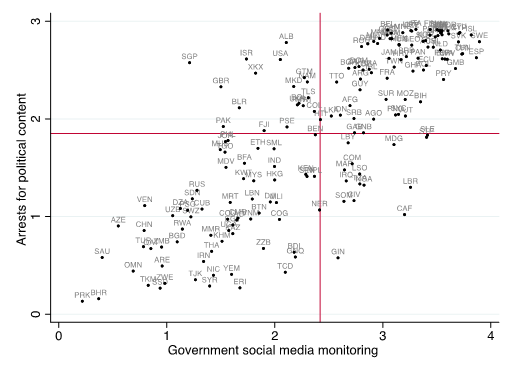

Figure 1: A scatterplot of two indicators: arrests for political content and government social media monitoring. A high score here means less arrests on the first indicator, and less monitoring on the second indicator (Digital Society Project).

By mitigating punishment for political content, while maintaining social media monitoring, these countries might be able to avoid the negative repercussions of social media censorship, maintaining an open forum for discussion while restricting violent content. Individuals might continue freely post political content as they do not maintain a fear of repercussions for doing so.

In democratic nations, social media censorship and monitoring might not operate under the same paradigms as in authoritarian nations. As compared to authoritarian nations, social media monitoring and censorship in democracies have a different goal. Thus, the virtue of being a democracy will effect the impact and usage of social media censorship. Censorship alone does not impact political engagement, but rather the environment in which it is applied. Thus, I propose,

**H1: Social media censorship in democratic countries will result in a lesser reduction of political action than in authoritarian countries.**

## Research Design

### Data

To measure social media censorship and monitoring, I will be utilizing variables from the VDem Dataset—an expert-coded data set that accounts for 202 countries. The variables of interest I am examining are from the Digital Society Survey, designed by the Digital Society Project. Social media, as coded for in this measurement, includes both publicly visible and private messaging platforms, including Facebook, Flickr, Friendstar, Google+, Instagram, Myspace, LinkedIn, Twitter, VKontakte, Weibo, Signal Slack, Snapchat, and WhatsApp. Censorship is does not include censorship of child pornography, military and intelligency sectrets, or defamatory speech, unless these measures are used as a pretext for censoring political information or opinions. Country behavior is coded on an ordinal scale of 0-4 for a variety of different traits related to digital society.

The measurement captures the subjective perception of experts about censorship within countries. It has the distinct drawback of not being based on quantifiable country behavior. However, in 2020 Digital Society Working Paper found that V-Dem scores for democratic countries were corroborated by publicly available Facebook and Google data for take-down request (Meserve and Pemstein 2020). While V-Dem data extends back to the early 2000s, however, the data on social media use is spotty in the early 2000s (Meserve and Pemstein 2020). Thus, I will limit my data usage from 2009-2024. Additionally, I will be utilizing V-Dem’s Regimes of the World (RoW) measure to classify countries on a scale of democratic to authoritarian.

The datasets for measuring country-level censorship are the same as those utilized in the paper “Government Digital Repression and Political Engagement: A Cross-National Multilevel Analysis” which concluded that higher levels of social media censorship caused lower political participation (Chan, Yi, and Kuznetsov 2024). Thus, I will be able to directly engage with these past findings.

### Variables

The variables of interest for this project are:

- *Government social media monitoring (v2smgovsmmon)*

  This variable measures the extent to which the government surveils social media content. I plan to create an index variable combining government social media shut down in practice, social media alternatives, social media monitoring, and social media censorship in practice. Lower values indicate higher rates of monitoring. This is common in V-Dem data, so that higher values indicate more democracy. In order to remedy this for my analysis I will reverse the scale so that my monitoring values is 1 - VDEM_monitoring.
- *Government social media censorship in practice (v2smgovsmcenprc)*

  This variable measures the extent to which the government actively censors political social media content. Lower values indicate higher rates of censorship. This is common in V-Dem data, so that higher values indicate more democracy. In order to remedy this for my analysis I will reverse the scale so that my censorship values is 1 - VDEM_censorship.
- *Types of organization through social media (v2smorgtypes)*

  These variables measure the presence of various modes of political organizing through social media. VDem codes for: petition signing, voter turnout, street protests, strikes/labor actions, riots, organized rebellion, vigilante justice, terrorism, and ethnic cleansing/genocide.
- *Regimes of the world – the RoW measure (v2x_regime)*

  This variable categorizes countries as either closed autocracies, electoral autocracies, electoral democracies, or liberal democracies. For this project I will be defining electoral democracies and liberal democracies as democratic states.
- *Average people’s use of social media to organize offline action (v2smorgavgact)*

  This variable measures specifically average people’s use of social media to organize offline violence. A higher value indicate a higher usage of social media.
- *Elites’ use of social media to organize offline action (v2smorgelitact)*

  This variable measures specificially “elites” usage of social media to organize political action. A higher value indicate a higher usage of social media.

I will create a z-score index variable combining social media monitoring and social media censorship called “Social media monitoring and censorship.” I will also create a z-score index variable combining the average person’s use of social media to organize political action and the elite person’s use of social media to organize political action called “Use of social media to organize political action.” I am specifically focused on how social media is utilized to organize political action, rather than actual instances of political action. It is important to note that just because calls for rebellion might be posted online, that doesn’t actually translate to real-life action. However, I am specifically interested in how indivdiual actors feel emboldened to utilize social media, and what content is seen online.

*Figure 2: Descriptive Statistics of Variables*

0 indicates non-democracy, 1 indicates democracy

Descriptive Table of Censorship

| regime_binary | mean | sd | range |
| --- | --- | --- | --- |
| 0 | 1.5765531 | 1.2543614 | 6.941 |
| 1 | -0.2786667 | 0.7613753 | 3.857 |

Descriptive Table of Social Media Monitoring

| regime_binary | mean | sd | range |
| --- | --- | --- | --- |
| 0 | 1.88673199 | 1.1231373 | 5.568 |
| 1 | -0.03874784 | 0.9750552 | 4.831 |

Descriptive Table of Political Action

| regime_binary | mean | sd | range |
| --- | --- | --- | --- |
| 0 | -0.3141828 | 2.308716 | 12.622 |
| 1 | 1.1776760 | 1.870794 | 11.350 |

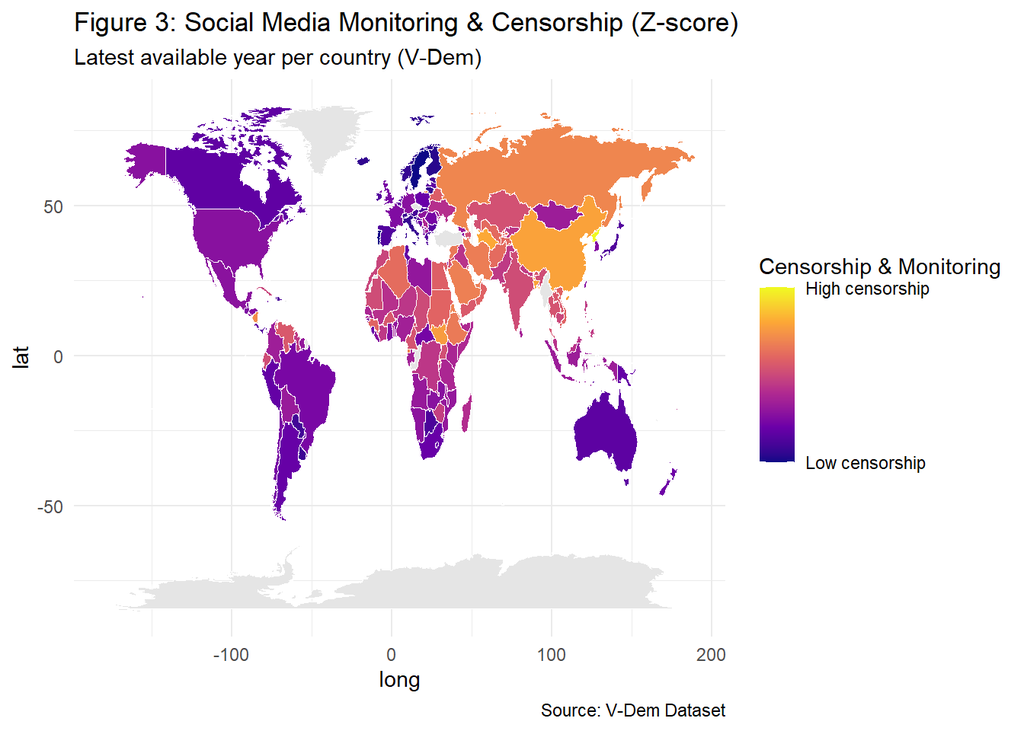

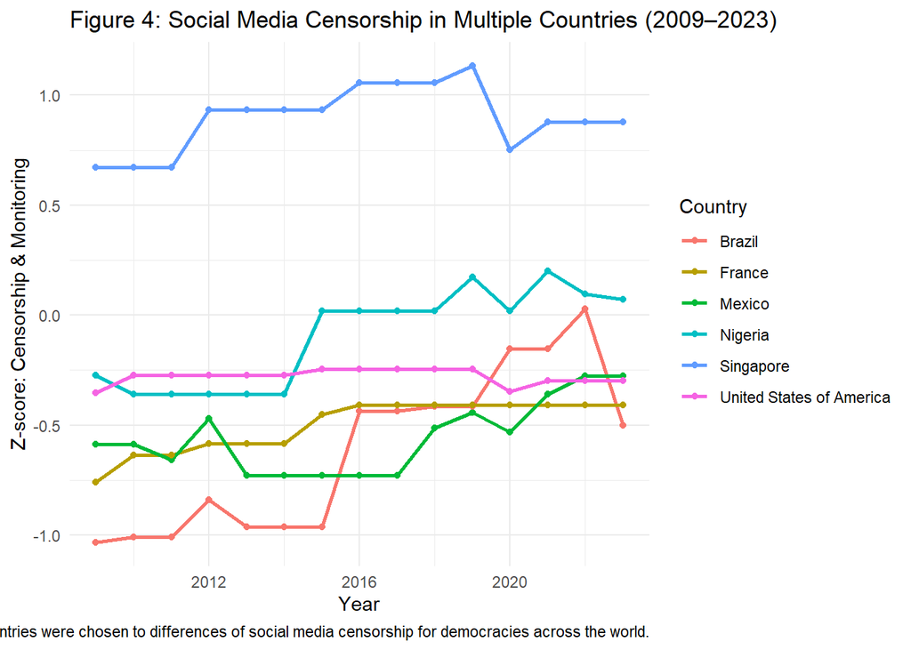

### Empirical Extension

Additionally, in order to support my theory that democracies have different motivations for censorship, I will examine how different types of political action, such as petition signing, are impacted differently from the more extremist uses of social media. If we see more democratic modes of political actions have been left untouched while more extreme modes have been negatively impact, one could argue that social media censorship, when employed under democratic premises, has the potential to fulfill its intended duty of quelling violence while maintaining a free forum of political speech.

### Regression Model

I will use interaction terms to measure how democracy impacts I will be using country-level fixed-effects and year-level fixed effects to account for potential confounders. Additionally, I will lag my independent variable, social media censorship, to strengthen my causal inference so that censorship precedes political action.

In short,

**Dependent Variable:** “Use of social media to organize political action,”

**Main Independent Variable:** “Social media monitoring and censorship”

**Moderator:** Democracy

**Interaction Term:** “Social media monitoring and censorship” x Democracy

$$PoliticalAction_it = β₀ + β₁·Censorship_{i,t−1} + β₂·Democracy_it + β₃·(Censorship_{i,t−1} × Democracy_it) + γ·X_it + α_i + δ_t + ε_it$$

## Findings

**Basic Linear Regression**

Basic Linear Model

|  | (1) |
| --- | --- |
| (Intercept) | 0.037* |
|  | (0.018) |
| lag_z_cens_mon | -0.377*** |
|  | (0.018) |
| Num.Obs. | 2504 |
| R2 | 0.145 |
| R2 Adj. | 0.145 |
| AIC | 6668.5 |
| BIC | 6686.0 |
| Log.Lik. | -3331.257 |
| RMSE | 0.92 |

+ p < 0.1, * p < 0.05, ** p < 0.01, *** p < 0.001

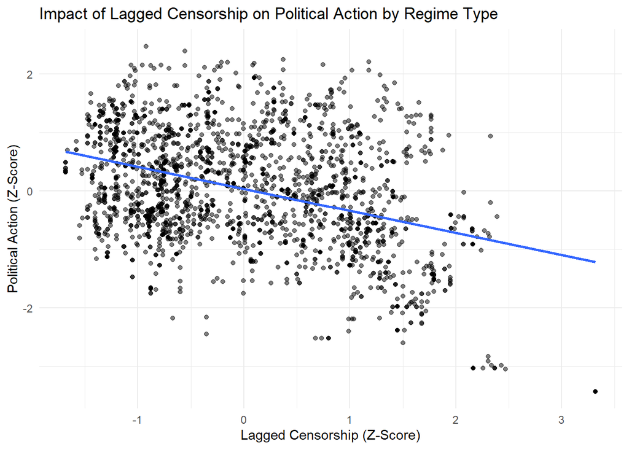

*Interpretation*

$\beta_1$ This means that increased social media censorship negatively and significantly associated with the use of social media to organize political action. This is statistically significant at a p-scoreof 0.001

This model asserts that increases in censorship are correlated with lower levels of political action. While this is what you would expect to find, the model assumes that there is not a confounding variables. In reality, however, civil society protections, regime types, and the likelihoods of arrests for political content are all potential confounders.

However, R2 is .145 which is relatively week, explaining only 14.5% of the data.

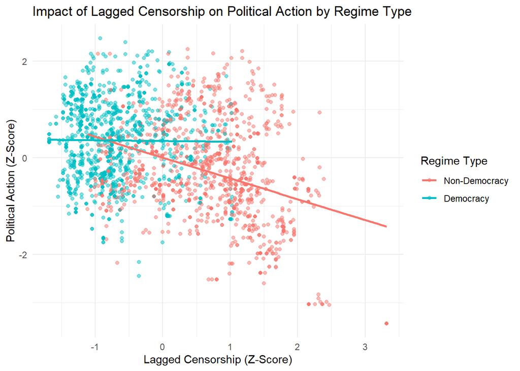

However, as figure 5 illustrates when we run the regression based on regime type, the negative correlation is only exhibited for non-democracies. Thus, in order to analyze the unique impact regime type has on political action, I will utilize interaction terms in order to address my hypothesis.

**Interaction Term**

Interaction Term Model

|  | (1) |
| --- | --- |
| (Intercept) | 0.005 |
|  | (0.034) |
| lag_z_cens_mon | -0.432*** |
|  | (0.031) |
| regime_binary | 0.345*** |
|  | (0.051) |
| lag_z_cens_mon × regime_binary | 0.417*** |
|  | (0.053) |
| Num.Obs. | 2504 |
| R2 | 0.175 |
| R2 Adj. | 0.174 |
| AIC | 6583.1 |
| BIC | 6612.3 |
| Log.Lik. | -3286.562 |
| RMSE | 0.90 |

+ p < 0.1, * p < 0.05, ** p < 0.01, *** p < 0.001

$β1 = -0.432$ is the effect of censorship on the usage of social media to organize political action when regime type is held constant. For non-democracies, which we are considering the base regime type, 1-unit increase in social media censorship is associated with a statististially signficant decrease in social media use for offline political action (at a 1% level) which suggests social media censorship has a negative relationship with social media usage for offline political action.

$\beta2 = 0.345$ This coefficient reflects the effect of regime type on social media usage for offline political action when censorship is held constant. There is a positive and statistically significant relationship between regime type and social media usage to organize offline political action. In other words, democracies show greater usage of social media for political action. This is statistically signficant at a 1% level.

However, R2 is .175 which is relatively week, explaining on 17.5% of the data.

**Fixed Effects**

Fixed Effects Regression

|  | (1) |
| --- | --- |
| lag_z_cens_mon | 0.018 |
|  | (0.114) |
| regime_binaryDemocracy | 0.148+ |
|  | (0.089) |
| lag_z_cens_mon × regime_binaryDemocracy | 0.198 |
|  | (0.126) |
| Num.Obs. | 2504 |
| R2 | 0.911 |
| R2 Adj. | 0.904 |
| R2 Within | 0.015 |
| R2 Within Adj. | 0.014 |
| AIC | 1387.3 |
| BIC | 2523.3 |
| RMSE | 0.30 |
| Std.Errors | by: country |
| FE: country | X |
| FE: year | X |

+ p < 0.1, * p < 0.05, ** p < 0.01, *** p < 0.001

*Interpretation*

$β1 = 0.018$ This coefficient reflect the impact of social media censorship on the usage of social media within countries over time, when regime type is held constant. Non-democratic countries, which we are considering the base regime type, whose political censorship increased above the sample mean had a 0.018 standard deviation increase in their usage of social media. This is not statistically significant. For non-democracies when controlling for country level changes over time, social media censorship results in no significant changes for offline political action.

$\beta_3 = 0.198$ the interaction term shows how the relationship how social media censorship differs for democratic countries versus non-democratic countries over time. Rather than a decline in political action, we see that democracies actually experience an increase in social media use for political action when there are increased levels of social media monitoring and censorship. This is not statistically significant

R2 is .911 which is relatively strong, explaining on 91.1% of the data.

## Empirical Extension

### Censorship vs. Monitoring

I will run my fixed effects, interaction term model on censorship and monitoring separately to see if different type of social media surveillance have different impacts on political action. I will continue to lag censorship and monitoring, and measure them as z-scores to standardize their comparison.

Fixed Effects Regression: Censorship

|  | (1) |
| --- | --- |
| lag_censorship | -0.001 |
|  | (0.023) |
| regime_binaryDemocracy | 0.132 |
|  | (0.085) |
| lag_censorship × regime_binaryDemocracy | 0.076* |
|  | (0.031) |
| Num.Obs. | 2098 |
| R2 | 0.897 |
| R2 Adj. | 0.888 |
| R2 Within | 0.024 |
| R2 Within Adj. | 0.023 |
| AIC | 1329.7 |
| BIC | 2267.4 |
| RMSE | 0.31 |
| Std.Errors | by: country |
| FE: country | X |
| FE: year | X |

+ p < 0.1, * p < 0.05, ** p < 0.01, *** p < 0.001

Fixed Effects Regression: Monitoring

|  | (1) |
| --- | --- |
| lag_monitoring | -0.006 |
|  | (0.021) |
| regime_binaryDemocracy | 0.126 |
|  | (0.081) |
| lag_monitoring × regime_binaryDemocracy | 0.087*** |
|  | (0.026) |
| Num.Obs. | 2350 |
| R2 | 0.908 |
| R2 Adj. | 0.900 |
| R2 Within | 0.031 |
| R2 Within Adj. | 0.030 |
| AIC | 1280.3 |
| BIC | 2340.5 |
| RMSE | 0.29 |
| Std.Errors | by: country |
| FE: country | X |
| FE: year | X |

+ p < 0.1, * p < 0.05, ** p < 0.01, *** p < 0.001

With both censorship and monitoring individually we see the same phenomenon, where within countries over time, social media censorship actually increases political action in democracies. This impact, however, is significantly lower—nearly negligible. However, it is statistically significant. Additionally, when we separate censorship and monitoring, the impact on non-democracies also disappears. While the larger trend remains, when we separate our index score, we see that the impact is reduced when we don’t group social media monitoring and censorship together.

Additionally, to see how censorship impacts different types of social media organized political action differently. I will run my same regression over a z-score of the different types of uses of social media for political action.

Effect of Lagged Censorship on Forms of Political Action (Standardized)

|  | petition | voting | protest | strike | riot | rebellions | vigilante | terrorism | genocide | other |
| --- | --- | --- | --- | --- | --- | --- | --- | --- | --- | --- |
| lag_z_cens_mon | -0.016 | -0.152 | -0.061 | 0.115 | 0.024 | 0.023 | 0.197* | -0.015 | -0.044 | 0.302** |
|  | (0.081) | (0.127) | (0.124) | (0.086) | (0.102) | (0.111) | (0.092) | (0.101) | (0.166) | (0.096) |
| regime_binaryDemocracy | -0.003 | 0.089 | 0.038 | 0.137 | -0.021 | -0.199* | -0.031 | -0.242*** | -0.129 | -0.002 |
|  | (0.066) | (0.112) | (0.072) | (0.099) | (0.111) | (0.078) | (0.099) | (0.061) | (0.093) | (0.070) |
| lag_z_cens_mon × regime_binaryDemocracy | 0.033 | 0.186 | 0.288* | -0.043 | 0.256 | 0.116 | -0.063 | -0.107 | 0.032 | -0.523*** |
|  | (0.102) | (0.151) | (0.129) | (0.117) | (0.159) | (0.127) | (0.127) | (0.112) | (0.145) | (0.143) |
| Num.Obs. | 2504 | 2504 | 2504 | 2504 | 2504 | 2504 | 2504 | 2504 | 2504 | 2504 |
| R2 | 0.852 | 0.757 | 0.827 | 0.821 | 0.761 | 0.764 | 0.767 | 0.840 | 0.752 | 0.807 |
| R2 Adj. | 0.840 | 0.738 | 0.814 | 0.808 | 0.743 | 0.746 | 0.749 | 0.828 | 0.733 | 0.792 |
| R2 Within | 0.000 | 0.006 | 0.009 | 0.006 | 0.008 | 0.009 | 0.008 | 0.012 | 0.002 | 0.029 |
| R2 Within Adj. | -0.001 | 0.004 | 0.007 | 0.004 | 0.007 | 0.008 | 0.007 | 0.011 | 0.001 | 0.027 |
| AIC | 2693.4 | 3926.6 | 3061.9 | 3165.3 | 3919.4 | 3878.9 | 3850.6 | 2882.4 | 3996.6 | 3343.9 |
| BIC | 3753.6 | 4986.9 | 4122.2 | 4225.5 | 4979.6 | 4939.1 | 4910.9 | 3942.6 | 5056.8 | 4404.2 |
| RMSE | 0.39 | 0.49 | 0.41 | 0.42 | 0.49 | 0.49 | 0.49 | 0.40 | 0.50 | 0.44 |
| Std.Errors | by: country | by: country | by: country | by: country | by: country | by: country | by: country | by: country | by: country | by: country |
| FE: country | X | X | X | X | X | X | X | X | X | X |

+ p < 0.1, * p < 0.05, ** p < 0.01, *** p < 0.001

## Discussion and Policy Implications

Moving forward, to strengthen my analysis of democratic and non-democratic censorship, I would additionally like to utilize some form of matching to compare countries of similar censorship scores. Moreover, my research was limited by the fact that I relied on expert-coded data which can be subjective. Examining the nature of protests following censorship utilizing social media data, where I could analyze the actual character of posts can provide greater insight. Additionally, analyzing the actual censorship and monitoring practices by looking tangible laws and measures in these nations can move this conversation from abstract ideas of censorship and monitoring toward considering specific policies and practices.

In democracies, the increased usage of social media to organize protests could be explained as a backlash to increased restraints on freedom. Democracies, maintaining civic freedoms, might allow for greater criticism of government measures, and individuals might feel more emboldened or entitled to fight for these freedoms. This project has pushed me to consider social media censorship and monitoring as a multi-faceted practice. It is easy to assume that censorship is inherently repressive, and in many cases it is. But sometimes, it part of a government’s duty in maintaining public safety. Misinformation and online radicalization are rampant issues in the news today. As democracies contend with what forms of content can be allowed online, they enter into the gray spaces of monitoring and censorship—a careful balancing act in the digital age.

## References

Chan, Michael, Jingjing Yi, and Dmitry Kuznetsov. 2024. “Government Digital Repression and Political Engagement: A Cross-National Multilevel Analysis Examining the Roles of Online Surveillance and Censorship.” *The International Journal of Press/Politics* 29 (2): 371–93. https://doi.org/10.1177/19401612221117106.

Deibert, Ron. 2015. “Authoritarianism Goes Global: Cyberspace Under Siege.” *Journal of Democracy* 26 (3): 64–78. https://muse.jhu.edu/pub/1/article/586479.

Deibert, Ronald, John Palfrey, Rafal Rohozinski, and Jonathan Zittrain. 2012. *Access Contested: Security, Identity, and Resistance in Asian Cyberspace*. Cambridge: The MIT Press. https://muse.jhu.edu/pub/6/oa_monograph/book/19777.

Horowitz, Jeff. 2023. *Broken Code*. Doubleday.

Meserve, Stephen A, and Daniel Pemstein. 2020. “Terrorism and Internet Censorship.” *Journal of Peace Research* 57 (6): 752–63. https://doi.org/10.1177/0022343320959369.

Ong, Elvin. 2021. “Online Repression and Self-Censorship: Evidence from Southeast Asia.” *Government and Opposition* 56 (1): 141–62. https://doi.org/10.1017/gov.2019.18.

Pan, Jennifer, and Alexandra A. Siegel. 2020. “How Saudi Crackdowns Fail to Silence Online Dissent.” *American Political Science Review* 114 (1): 109–25. https://doi.org/10.1017/S0003055419000650.

Reuter, Ora John, and David Szakonyi. 2015. “Online Social Media and Political Awareness in Authoritarian Regimes.” *British Journal of Political Science* 45 (1): 29–51. https://doi.org/10.1017/S0007123413000203.

Ruijgrok, Kris. 2017. “From the Web to the Streets: Internet and Protests Under Authoritarian Regimes.” *Democratization* 24 (3): 498–520. https://doi.org/10.1080/13510347.2016.1223630.

“Social Media Surveillance by the U.S. Government Brennan Center for Justice.” n.d. Accessed April 5, 2025. https://www.brennancenter.org/our-work/research-reports/social-media-surveillance-us-government.

Zeitzoff, Thomas. 2017. “How Social Media Is Changing Conflict.” *Journal of Conflict Resolution* 61 (9): 1970–91. https://doi.org/10.1177/0022002717721392.